# Feature Engineering

Christos Chen, Jasmine Dogu, Brian Wimmer

Janurary 7, 2021

# Research Question and Hypotheses

**Goal**: Through this project, our group hopes to utilize both the **Support Vector Machine** (SVM) and **Random Forest Classifier** models to predict whether a person is or is not going to get the H1N1 vaccine. These two algorithms were selected for the reasons that are provided below in the “Why Support Vector Machine and Random Forest Classifier” section.

We will first begin by explaining some background information on the H1N1 virus, the dataset, and the two machine learning algorithms. From there, we will proceed with the model creation and the parameter tuning. Lastly, we will draw conclusions from our findings and discuss future applications.

**General Question**: Will the SVM or the Random Forest Model Predict the Likelihood of a Person Getting the H1N1 Vaccine Better?

**Null Hypothesis**: The SVM Polynomial Kernel will not outperform the Random Forest Classifier Model with regards to its F1 Score **Alternative Hypothesis**: The SVM Polynomial Kernel will outperform the Random Forest Classifier Model with regards to its F1 Score

**Note**: The F1 score was the metric used to primarily evaluate the two models. To determine if the F1 scores are statistically significant, a **t-test** will be utilized.

# Feature Selection

## Corellogram

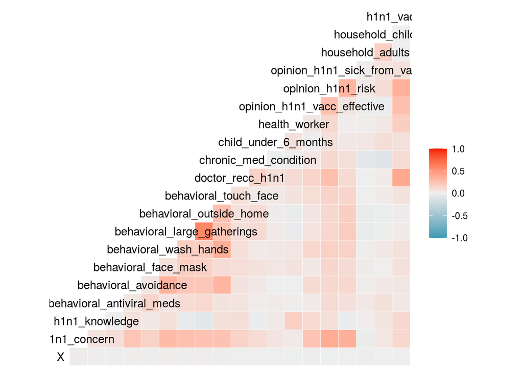

Because we determined that no variables were highly correlated, we will not have to remove any of the features and can move on to the LASSO Regression.

## LASSO Regression Model

### Why LASSO Regression

Initially, we want to utilize lasso regression to reduce the feature space. LASSO regression is an analysis method that utilizes both variable selection and regularization to further enhance the predictive accuracy and interpretability. It imposes a constraint on the model parameters that causes the regression coefficients for some of the variables to shrink towards zero.

### Computing Penalized Logistic Regression

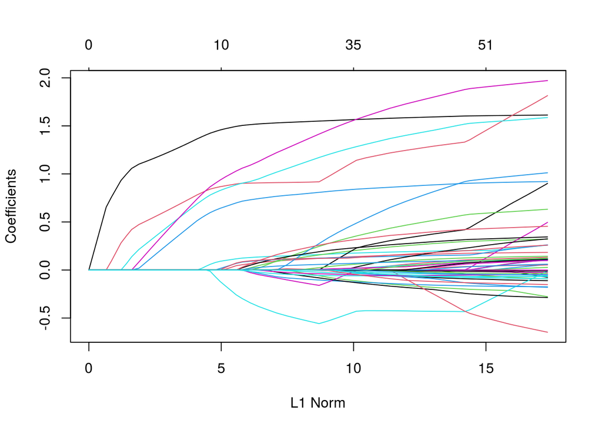

```
##                           name coefficient
## 2            doctor_recc_h1n11   0.8139730
## 3 opinion_h1n1_vacc_effective5   0.1541054
## 1                  (Intercept)  -1.4715994
```

```
##
## Call:  cv.glmnet(x = x, y = y)
##
## Measure: Mean-Squared Error
##
##       Lambda Measure       SE Nonzero
## min 0.000398  0.1259 0.001723      52
## 1se 0.007821  0.1275 0.001848      25
```

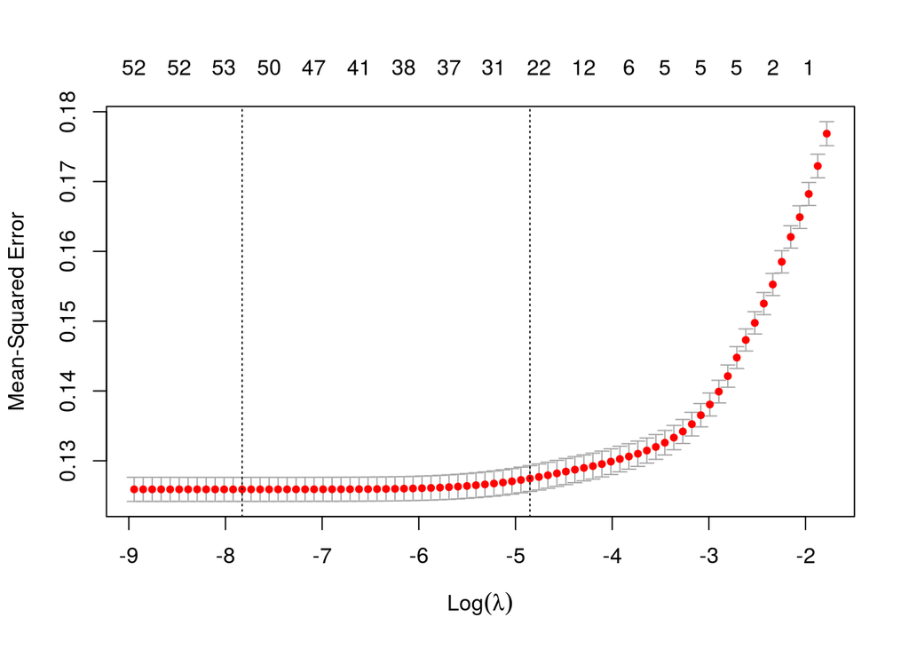

```
## [1] 0.0003984087
```

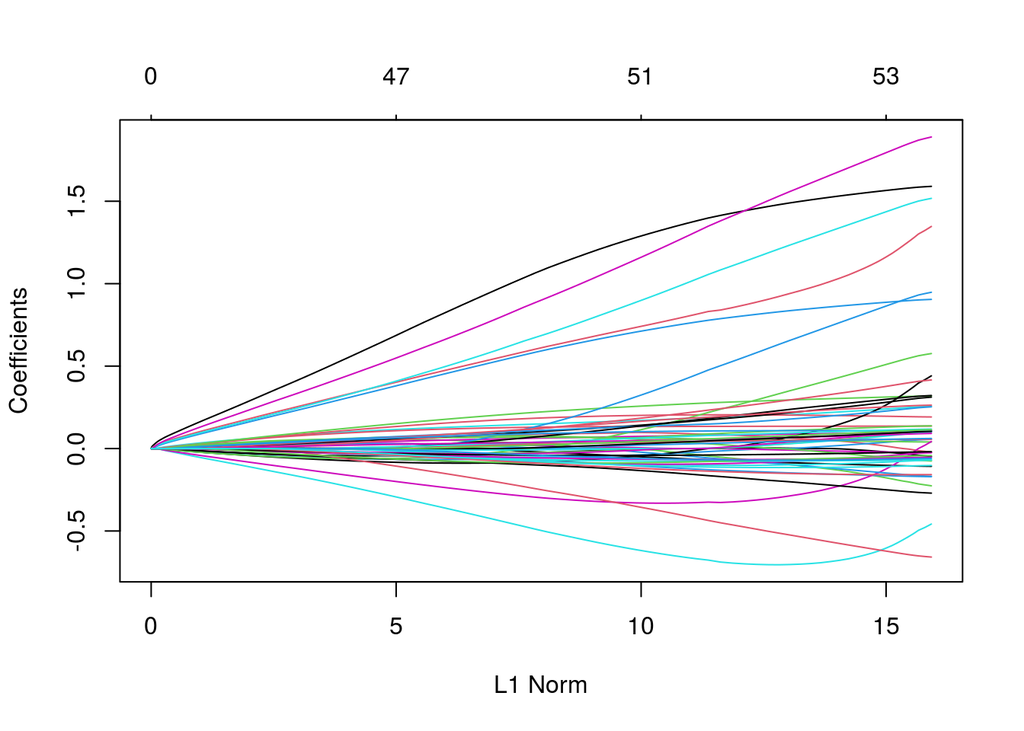

```
##                             name coefficient
## 24            opinion_h1n1_risk5 0.299031242
## 13             doctor_recc_h1n11 0.287688519
## 23            opinion_h1n1_risk4 0.221305610
## 20  opinion_h1n1_vacc_effective5 0.196000868
## 16                health_worker1 0.143618320
## 22            opinion_h1n1_risk3 0.100527581
## 21            opinion_h1n1_risk2 0.056821821
## 32            age_group65+ Years 0.056044008
## 19  opinion_h1n1_vacc_effective4 0.047479900
## 15         child_under_6_months1 0.043202403
## 31        age_group55 - 64 Years 0.041549360
## 37         raceOther or Multiple 0.032947522
## 34     educationCollege Graduate 0.031696679
## 38                     raceWhite 0.030199818
```

[output cut: 16 more lines]

### Creating a Lasso Coefficient Plot

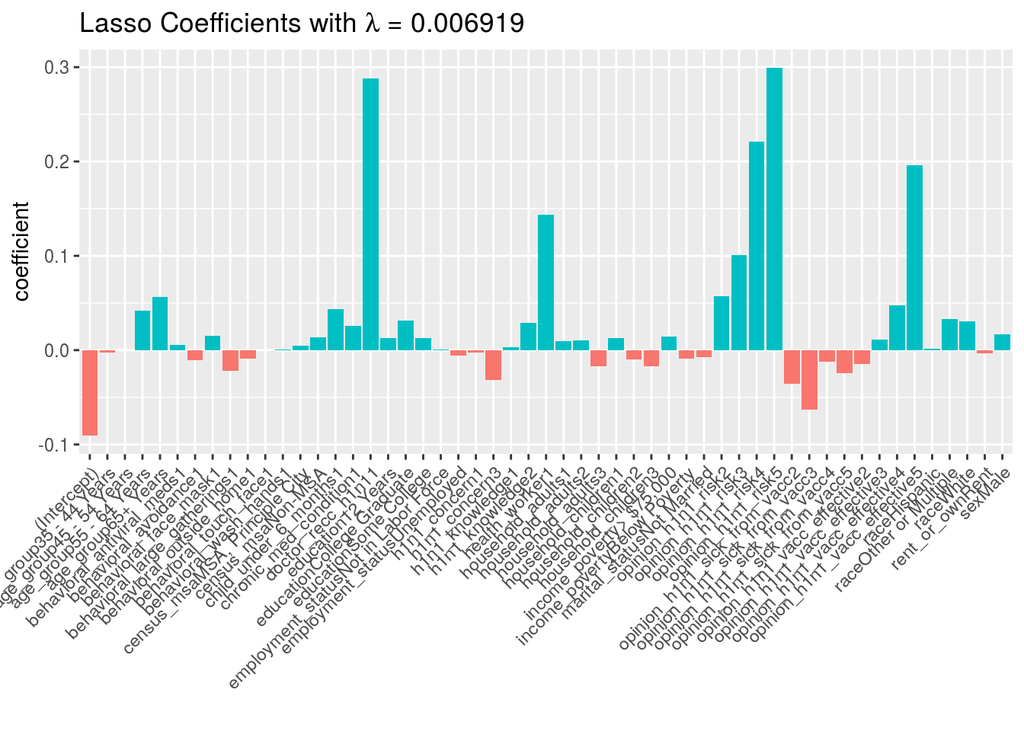

# Isolate Variables of Interest

```
##  [1] "opinion_h1n1_risk5"           "doctor_recc_h1n11"
##  [3] "opinion_h1n1_risk4"           "opinion_h1n1_vacc_effective5"
##  [5] "health_worker1"               "opinion_h1n1_risk3"
##  [7] "opinion_h1n1_risk2"           "age_group65+ Years"
##  [9] "opinion_h1n1_vacc_effective4" "child_under_6_months1"
## [11] "age_group55 - 64 Years"       "raceOther or Multiple"
## [13] "educationCollege Graduate"    "raceWhite"
## [15] "h1n1_concern3"                "opinion_h1n1_sick_from_vacc2"
## [17] "opinion_h1n1_sick_from_vacc3"
```

As can be seen above, there are 17 variables that we plan to utilize within our SVM model. This significant reduction of the feature space promotes sparsity and makes the model *“mean and lean”* as described by Professor Wright.

# One-Hot Encoding

```
##   opinion_h1n1_risk5 doctor_recc_h1n11 opinion_h1n1_risk4
## 1                  0                 0                  0
## 2                  0                 0                  1
## 4                  0                 0                  0
## 5                  0                 0                  0
## 6                  0                 0                  0
## 7                  0                 0                  0
##   opinion_h1n1_vacc_effective5
## 1                            0
## 2                            1
## 4                            0
## 5                            0
## 6                            1
## 7                            0
```

# Future Direction for Project

Utilizing both the polynomial kernel and the radial kernel, we will explore tuning the hyperparameters and comparing the performance of each as they both possessed similar RMSE values. We initially ran multiple kernels and selected the Polynomial Kernel due to its low RMSE of 0.401, with the Radial Kernel following close behind at an RSME of 0.417. However, because these kernel’s performed very similarly with regard to our loss function, we would still like to further assess both kernels.

Following the execution of the SVM, we would like to proceed with the Random Forest and aim to tune the hyperparameters for optimal performance. Having tuned both of the models, the statistical significance of the resulting F1 Scores of each algorithm will be assessed for statistical significance with a t-test.

# Creating the Training, Testing, and Validation Sets

We chose a 70/15/15 split for our analysis, due to a variety of beneficial factors. 70% training data allows for ample examples for our model to find the most accurate solutions during the testing phase. 70% allocates enough “practice” data, while still leaving ample data for use later. In addition, 15% of validation data allows us enough space to choose the best model without giving up more training data. Finally 15% of test data, in our opinion, is the perfect sweet spot to test our model to unseen data. This 15% of test data should be accurate after undergoing the training and validation sets.

# SVM Model

## Original data - SVM Polynomial Kernel

### Confusion Matrix

```
## Confusion Matrix and Statistics
##
##           Reference
## Prediction    0    1
##          0 2242   14
##          1  631   61
##
##                Accuracy : 0.7812
##                  95% CI : (0.7658, 0.796)
##     No Information Rate : 0.9746
##     P-Value [Acc > NIR] : 1
##
##                   Kappa : 0.1186
##
##  Mcnemar's Test P-Value : <2e-16
##
##             Sensitivity : 0.81333
##             Specificity : 0.78037
##          Pos Pred Value : 0.08815
##          Neg Pred Value : 0.99379
##              Prevalence : 0.02544
##          Detection Rate : 0.02069
##    Detection Prevalence : 0.23474
##       Balanced Accuracy : 0.79685
##
##        'Positive' Class : 1
##
```

```
## [1] 0.1690621
```

Our primary metric, the F1 Score, was calculated to be 0.169 - this is awful. Let’s try it with the radial kernel.

## Original data - SVM Radial Kernel

### Confusion Matrix

```
## Confusion Matrix and Statistics
##
##           Reference
## Prediction    0    1
##          0 2149  107
##          1  405  287
##
##                Accuracy : 0.8263
##                  95% CI : (0.8122, 0.8398)
##     No Information Rate : 0.8664
##     P-Value [Acc > NIR] : 1
##
##                   Kappa : 0.4318
##
##  Mcnemar's Test P-Value : <2e-16
##
##             Sensitivity : 0.72843
##             Specificity : 0.84143
##          Pos Pred Value : 0.41474
##          Neg Pred Value : 0.95257
##              Prevalence : 0.13365
##          Detection Rate : 0.09735
##    Detection Prevalence : 0.23474
##       Balanced Accuracy : 0.78493
##
##        'Positive' Class : 1
##
```

```
## [1] 0.5483842
```

However, our main metric, the *F1 Score*, is *0.5483*. This is a significant improvement from the the polynomial kernel! Let’s try with the reduced features!

## SVM Model w/ Feature Reduction

## Reduced Features - SVM Polynomial Kernel

### Confusion Matrix

[output not shown]

```
## [1] 0.1817421
```

With regard to our key metric, the F1 Score improved from 0.1817 , which is still awful. Now, we will set to tuning the hyperparameters, using the original data that did not have a reduced feature space.

# Tuning Hyperparameters

```
##
## Parameter tuning of 'svm':
##
## - sampling method: fixed training/validation set
##
## - best parameters:
##  gamma cost
##    0.5    4
##
## - best performance: 0.2258393
##
## - Detailed performance results:
##   gamma cost     error dispersion
## 1   0.5    4 0.2258393         NA
## 2   1.0    4 0.2349949         NA
## 3   2.0    4 0.2349949         NA
## 4   0.5    8 0.2258393         NA
## 5   1.0    8 0.2349949         NA
## 6   2.0    8 0.2349949         NA
## 7   0.5   16 0.2258393         NA
## 8   1.0   16 0.2349949         NA
## 9   2.0   16 0.2349949         NA
```

## Optimal Parameter Plot

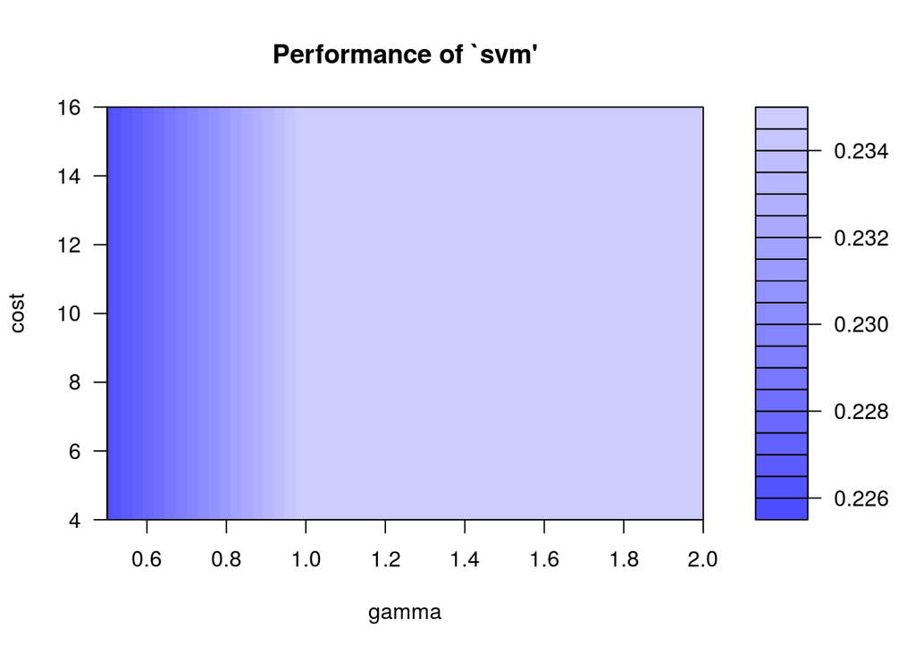

As can be see above, the optimal gamma is 0.5 and the cost was 4!

## Original data - Tuned SVM Radial Kernel

### Confusion Matrix

[output not shown]

```
## [1] 0.3650852
```

The F1 Score unfortunately, decreases the F1 Score by ~ 0.2 to 0.365.